# Introduction to Regression

I can’t wait to explore regression analysis with you. Together, we’ll learn how data professionals go from a problem to actionable insights using regression analysis techniques. We’ll begin by introducing regression analysis. The focus for regression analysis is about understanding relationships between variables. We’ll use the pace framework; plan, analyze, construct, and execute, to guide us through the rest of the course. Next, you’ll have the chance to apply pace to simple linear regression, which will be our first model we explore comprehensively. We’ll go over the entire process from beginning to end, using different scenarios and data. Then we’ll examine multiple linear regression closely. Multiple linear regression expands upon a lot of the concepts from simple linear regression, but will allow us to problem-solve a larger variety of questions. We will focus on some more nuanced topics like variable selection and model interpretation. We’ll also consider a few hypothesis tests, such as chi-squared test and ANOVA. These tests will help us explore different groups in the data, allowing us to glean interesting insights. Finally, we will review the fundamentals of logistic regression. This is the last and most complex model, which will set you up well to approach the rest of the program on machine-learning. Whenever you’re ready, I’m excited to get started on the next video.

# 1 PACE in regression analysis

You may be familiar with terms like machine-learning models or regression analysis. If not, you’re in the right program. Next up, we’ll get started on our learning journey. To begin, we’re going to discuss a few key terms and definitions.

Regression models are based on a statistical foundation. Models used in the data career space are a family of techniques that rely on existing information or data points to inform what we might think other data points will look like. The goal is always to tell a story about the relationships between the variables in the data. The story will help stakeholders adjust their business strategy and decisions.

Modeling follows an iterative process. You may be familiar with other frameworks, such as the data life cycle or the six steps of exploratory data analysis. In this course, we will cover each step of the modeling process using PACE. Outlined earlier in this program, PACE, plan, analyze, construct, and execute, provides us with the foundation for conducting regression analysis. Let’s take some time to preview how PACE works in the context of regression analysis.

In regression modeling, the **plan** stage is about understanding your data in the problem context. Knowledge you bring, whether from industry or others, can be instrumental in the plan stage. By considering what data you have access to, how the data was collected, and what the business needs are, you’ll be able to strategically analyze, construct, and execute the rest of your work. The plan stage will guide the other three stages of PACE.

After you plan, you have to **analyze**. In this stage, you examine your data more closely so you can choose a model or a couple of models you think might be appropriate. When working with regression analysis, this is where you use Python to perform EDA and check the model assumptions as needed. **Model assumptions are statements about the data that must be true to justify the use of particular data techniques.** As a data professional, you will use statistics to check whether model assumptions are met. A good understanding of statistics gives data professionals the power to construct meaningful models.

After you analyze, you must **construct**. For regression analysis, this is where you actually build the model in Python or your coding language of choice. This step involves selecting variables, transforming the data as needed, and writing code. Even though you checked model assumptions before you built the model, many model assumptions need to be rechecked after the model is built. You’ll do that in the construct phase as needed. The last part of construct phase is evaluating the model results. At this point, you are answering the questions, how good is my model? You’ll choose metrics, compare models, and get preliminary results. Then based on your evaluation, you can use EDA to refine your model accordingly.

Of course, as a data professional, you must first and foremost be an honest storyteller. Studying the results produced by the regression will uncover relationships within your data and help you discover insights to tell the full story. This leads to the last part of PACE, **execute**.

You’ll interpret everything you learned from analyzing and constructing to share the story. You’ll prepare formal results and visualizations and share them with stakeholders. To do this, you’ll convert model statistics into statements describing the relationship between the variables in the data. These descriptions must consider the context and initial questions from the plan phase. At the center of everything is data. The PACE framework helps data professional stay organized. The insights data professionals produced must be data-driven and accurate and they have to make sense given the business or community contexts.

We’ll go over these steps using examples later in the course, but PACE is iterative. As you grow as a data professional, your experience will help you decide when to pivot between stages of PACE. You might switch the order or repeat steps depending on the situation.

Now that we’ve laid out the pieces of the modeling puzzle, we can talk about how correlation and regression are related. Then we will explore two foundational regression models, linear and logistic regression. These models will be covered in more depth in later videos. This overview will provide you with a solid basis of understanding. Time to start putting together our puzzle. Don’t forget your statistical grammar tools, you’ll need them.

# 2 Introduction to linear regression

Many patterns that you’ve observed in daily life can be expressed using linear regression models, which is pretty cool. For example, as a version of computer software gets older, online searches for that software version may decrease. As a social media personality gains followers, their book sales increase. These relationships can be modeled using a linear regression.

The linear in linear regression indicates the relationship we can visualize on a graph, a line. A line is a collection of an infinite number of points extending in two opposite directions. In a graph, the individual points show up as a line, and we only see a portion of the line.

Linear regression is a technique that estimates the linear relationship between a continuous dependent variable $y$ and one or more independent variables $x$.

For example we could model the relationship between the prices of a product and the number of sales. Our $y$ variable would be the number of sales and our $x$ variable would be the prices.

In an earlier course, you learned the difference between continuous and categorical variables. As a reminder, continuous variables are variables that can take on any real value between its minimum and maximum value. For example product sales, vehicle speed, and time spent on a webpage are all continuous variables. Whereas types of products and educational level are not. These are categorical. Categorical variables have a finite number of possible values. While linear regression allows us, as data analytics professionals to estimate continuous dependent variables. There are other regression models that let us estimate categorical variables. We’ll learn more about those in a later course.

Throughout this course, we’ll talk about dependent and independent variables.

**The dependent variable is the variable a given model estimates.** Sometimes the dependent variable is also called a response or outcome variable and is commonly represented with the letter $y$. We assume that the dependent variable tends to vary based on the values of independent variables, typically represented by an $x$.

**Independent variables are also referred to as explanatory variables or predictor variables**. For example, let’s say you’re working at a cake shop and you’re trying to understand the factors that contribute to cake sales. The dependent or $y$ variable would be the number of cakes slices sold on any given day. An independent or $x$ variable could be how many cups of coffee are sold that day. Maybe as more coffee is purchased, more cake is also purchased.

In linear regression, you might encounter two more terms, slope and intercept.

The **slope** refers to the amount we expect $y$, the dependent variable, to increase or decrease per one unit increase of $x$, the independent variable.

The **intercept** is the value of $y$, the dependent variable when $x$, the independent variable equals 0.

Going back to cake and coffee, the slope would be how many slices of cake are purchased per cup of coffee purchase. The intercept would be the number of cakes slices that are sold when zero cups of coffee are sold.

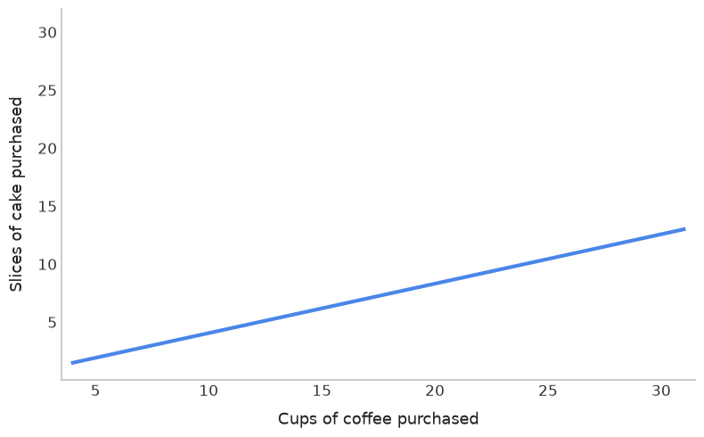

```python
import matplotlib.pyplot as plt
import numpy as np

# Set figure size and resolution
plt.figure(figsize=(8, 5), dpi=100)

# Line parameters estimated from the image:
# At x = 4, y ≈ 1.5; at x = 31, y ≈ 13
x = np.array([4, 31])
y = 0.426 * x - 0.204  # Linear fit equation y = mx + b

# Plot regression line
plt.plot(x, y, color='#4a86e8', linewidth=3)

# Axis limits to match the slide
plt.xlim(3.5, 31.5)
plt.ylim(0, 32)

# Axis ticks and labels
plt.xticks(np.arange(5, 31, 5), fontsize=12, color='#333333')
plt.yticks(np.arange(5, 31, 5), fontsize=12, color='#333333')

plt.xlabel('Cups of coffee purchased', fontsize=13, labelpad=10, color='#222222')
plt.ylabel('Slices of cake purchased', fontsize=13, labelpad=10, color='#222222')

# Style adjustments to mirror the clean slide layout (remove top & right spines)
ax = plt.gca()
ax.spines['top'].set_visible(False)
ax.spines['right'].set_visible(False)
ax.spines['left'].set_color('#cccccc')
ax.spines['bottom'].set_color('#cccccc')
ax.spines['left'].set_linewidth(1.5)
ax.spines['bottom'].set_linewidth(1.5)

# Remove grid and tick marks for minimal aesthetic
plt.tick_params(axis='both', which='both', length=0)

plt.tight_layout()
plt.show()
```

**When two variables,** $x$ and $y$, are related in a linear way, we say they are correlated.

Using statistics, we can actually calculate how strong the linear relationship between $x$ and $y$ is. Pretty cool.

There are two kinds of correlation, positive and negative. Positive correlation is a relationship between two variables that tend to increase or decrease together. For example as more cups of coffee or purchased, more cakes slices are purchased.

Negative correlation, on the other hand, is an inverse relationship between two variables. When one variable increases, the other variable tends to decrease. The reverse is true too.

For example, let’s say you’re still working at the cake shop and you’re estimating how often to refill the iced coffee dispenser. You can model the relationship between iced coffee and hot coffee sales. As hot coffee sales increase, you might notice iced coffee sales tend to decrease, or perhaps you’re working at a media company and you’re analyzing readership. As the length of news articles increases, the number of people that finish reading the article might decrease. This is also an example of negative correlation.

Identifying these kinds of relationships can be incredibly useful in the workplace and in everyday life. Determining linear relationships helps us answer questions such as, which factors are associated with an increase or decrease in product sales? Which factors make a social service providers increase resources in a given region? Which factors lead to more or less demand for public transportation? In the cases mentioned, how big the slope of the regression is, tells us how much sales, resource allocation, and public transportation increase or decrease. Using linear regression, you can help answer similar questions in any industry.

However, it is important to note that correlation is not causation. For example in your cake shop, people buying coffee does not cause cake sales to increase. When modeling variable relationships, a data scientist must be mindful of the extent of their claims.

**Causation describes a cause and effect relationship where one variable directly causes the other to change in a particular way. Proving causation statistically requires much more rigorous methods and data collection than correlation.** For a data professional, the distinction between correlation and causation is especially important when presenting results. For example although we can say that as someone gets older, the number of places they have visited tends to rise. We cannot necessarily say that someone’s age causes the number of places they had visited to increase. There could be other factors causing you to travel more that coincide with your aging, such as visiting family or traveling more for work. Any of these factors could be correlated to aging, but it’s hard to say whether age or other factors are causing the traveling.

Articulating that correlation is not causation is part of a data professionals best practices and ethical toolbox. Both correlational and causal relationships provide useful insights. Regression analysis helps data analytics professionals tell nuanced stories without needing to prove causation.

That concludes a high-level overview of your first modeling technique. To recap, linear regression is a way to model linear relationships.

- Dependent variables vary according to independent variables.
- The slope identifies how much the dependent variable changes per one unit change in the independent variable.
- Positive and negative correlation describe linear relationships between variables.
- Always be mindful when interpreting regression results. Correlation is not causation.

There are lots of linear relationships in the world and in industry. In this video, we’ve provided just a few examples, but there are plenty more. That’s all for now. Next we’ll address the math behind linear regression. Your ever-growing statistical foundations will help you explain regression results in the clearest way possible.